# 729 周六作业

1.通过input输入一个字符，并判断它的类型，然后输出它是什么类型。 可以无限次输入，直至自己输入‘退出’才会结束。 例如：

- [1,24] --->print('您输入的是列表')
- Csd --->print('您输入的是字符串')

```python
while 1:

    str = input("请输入字符（'退出'字符串为结束）：") #输入，‘退出’为结束的输入

    if str == '退出':   #退出
        break

    try:
        str = eval(str)   #消掉字符串的的引号，得到值。如何出现异常，类型为字符串
    except:
        print('您输入的是字符串')
        continue

    #判断数据类型
    if type(str) == list:
        type_name='列表'
    elif type(str) == set:
        type_name = '集合'
    elif type(str) == tuple:
        type_name = '元组'
    elif type(str) == int:
        type_name = '正数型'
    elif type(str) == float:
        type_name = '浮点数型'
    elif type(str) == bool:
        type_name = '布尔型'
    elif type(str) == dict:
        type_name = '字典'
    print(f'您输入的是{type_name}')
```

[output not shown]

2.将字符串 去重并从小到大排序输出， 排序可用sorted()。 例如

- s = “ajldjlajfdljfddd”---->”adfjl”。

```python
input_str = input('请输入：')
str_de = set(input_str)   #去重
str_sort = sorted(str_de) #排序
out_str = ''.join(str_sort)  #合并为一个字符串
print(out_str)
```

```
请输入：ajldjlajfdljfddd
adfjl
```

3.根据num.txt，设计函数，计算每个小列表里面的平均人数。 例如：

- ['1000人以上'] ----> 1000
- ['50-150人'] ----> （150+50）/2 = 100,
- [''] ----> 0 最终结果保存在列表中，例如：[['50-150人'], [''],['1000人以上'] ] --> [100,0,1000,...]

```python
#读取num.txt文件
with open('./data/num.txt','r') as f:
    data = f.read()
```

```python
#数据处理
data = data.replace("'",'').replace('-',',').replace('人','').replace('以上','').replace('少于','').replace('\\','')  #去掉不需要的字符，处理后："[10000]"
num_deal = eval(data) #把处理过的结果,消除引号变成列表
num_deal
```

```
['[10000]',
 '[50,150]',
 '[10000]',
 '[150,500]',
 '[10000]',
 '[500,1000]',
 '[10000]',
 '[5000,10000]',
 '[500,1000]',
 '[150,500]',
 '[1000,5000]',
 '[150,500]',
 '[10000]',
 '[10000]',
 '[10000]',
 '[1000,5000]',
 '[1000,5000]',
 '[10000]',
 '[150,500]',
 '[500,1000]',
 '[150,500]',
 '[500,1000]',
 '[10000]',
 '[50,150]',
 '[50,150]',
 '[50,150]',
 '[50,150]',
 '[500,1000]',
 '[150,500]',
 '[1000,5000]',
 '[150,500]',
 '[50,150]',
 '[10000]',
 '[]',
 '[50,150]',
 '[150,500]',
 '[500,1000]',
 '[50,150]',
 '[500,1000]',
 '[1000,5000]',
```

[output cut: 946 more lines]

```
 '[50]',
 '[500,1000]',
 '[50]',
 '[50]',
 '[50,150]',
 '[50,150]',
 '[50]',
 '[]',
 '[50]',
 '[150,500]',
 '[50,150]',
 '[50,150]',
 '[50]',
 '[1000,5000]',
 ...]
```

```python
num_out = []  #存放输出的结果
for i in num_deal:
    try:
        temp = eval(i)   #消掉字符串的引号，得到列表。存在[]，导致出现异常
    except:
        pass
    if len(temp) == 0:  #表示['']
        num_out .append(0)   #把值添加到num列表中
    elif len(temp) == 1:   #一个数据
        num_out .append(temp[0])
    elif len(temp) == 2:    #两个数据，如100-1000
        num_out .append(int((temp[0]+temp[1])/2))
print(num_out )
```

```
[10000, 100, 10000, 325, 10000, 750, 10000, 7500, 750, 325, 3000, 325, 10000, 10000, 10000, 3000, 3000, 10000, 325, 750, 325, 750, 10000, 100, 100, 100, 100, 750, 325, 3000, 325, 100, 10000, 0, 100, 325, 750, 100, 750, 3000, 100, 50, 50, 7500, 325, 750, 50, 100, 50, 50, 100, 3000, 7500, 50, 750, 100…
```

4.定义了一个 Car 类，它有 brand、model 和 year 属性，表示汽车的品牌、型号和制造年份。还有 speed 属性表示当前车速。 类中定义三个方法：accelerate（加速）、brake（刹车）和 get_speed（获取速度）。

- accelerate可以输入加速参数increment表示加速了多少，输出经过加速后汽车的速度
- brake可以输入参数decrement表示减速了多少，输出减速后的汽车速度
- get_speed可以获取当前汽车的速度

```python
class Car:
    '''
    :param brand: 字符串
    :param model: 字符串
    :param year: 字符串
    :param speed: 浮点数
    '''
    def __init__(self, brand, model, year, speed):
        self.brand = brand
        self.model = model
        self.year = year
        self.speed = speed

    def accelerate(self, increment):  #加速,increment加速
        self.speed = self.speed+increment
        if self.speed > 250:         #汽车的最快速度设置为250km/h
            self.speed = 250
        print(f'加速{increment}，当前的速度为{self.speed}km/h')

    def brake(self, decrement):  #刹车，减速
        self.speed = self.speed-decrement
        if self.speed < 0:
            self.speed = 0
        print(f'减速{decrement},当前速度为{self.speed}km/h')

    def get_speed(self): #获取速度
        print(f'当前速度为{self.speed}km/h')
```

```python
car = Car(brand='宝马',model='xxxx', year='xxx',speed=20)
car.accelerate(100)
car.brake(50)
car.get_speed()
car.accelerate(1000)
```

```
加速100，当前的速度为120km/h
减速50,当前速度为70km/h
当前速度为70km/h
加速1000，当前的速度为250km/h
```

5.内容判断

a = [1,2,3] 与 b = [3,2,1]，两个列表中的内容是一样的，怎么判断出来？

提示：集合

```python
a = [1,2,3]
b = [3,2,1]
if len(a) != len(b):  #通过len（）查看两个列表的长度是否相同，不相同则判断为内容不一样
    print('内容相同')
else:
    if len(set(a)-set(b)) == 0:  #通过两个列表转换成集合，并通过看他们差集是否为空
        print('内容相同')
    else:
         print('内容不相同')
```

```
内容相同
```

6.（os、shutil模块的内容） 创建一个函数copy_directory，传入两个参数source_dir、destination_dir分别表示源文件夹和目标文件夹。 该函数作用是判断目标文件夹是否存在，如果不存在则新建，如果存在则把源文件夹下所有的内容复制到目标文件夹里面。

```python
import os
import shutil
def copy_directory(source_dir, destination_dir): #路径为绝对路径
    if not os.path.exists(destination_dir):  #判断目标文件夹是否存在
        os.mkdir(destination_dir)  #新建目标文件夹
    else:
        for i in os.listdir(source_dir): #得到源文件下的所有文件名称并一个个文件进行复制
            try:
                shutil.copy(source_dir+'//'+i, destination_dir) #复制到目标文件夹下
            except:
                print(source_dir+'//'+i+'文件复制失败')
        print('复制成功')
```

```python
destination_dir = './newdata'
source_dir = './data'
copy_directory(source_dir, destination_dir)
```

```
复制成功
```

7.（有难度，可以不做）python程序设计思维，井字棋游戏：构建棋盘3X3的棋盘，X和O分别下棋，当三个棋连成线时胜出。已在board中给出棋盘的位置以及初始的字符串,并可以通过print_board()打印每次下棋后的棋盘结果。

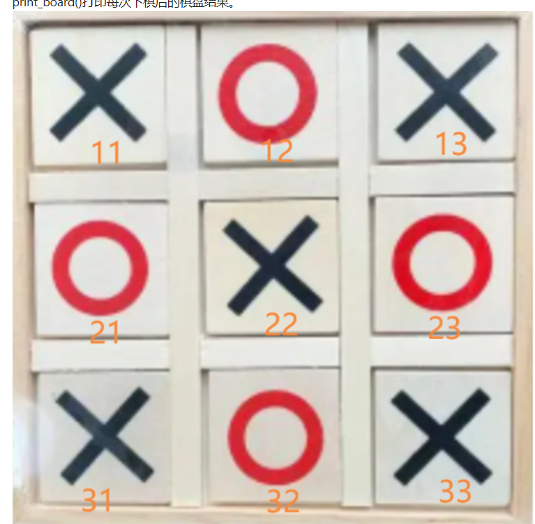

思路：

- A. 11，12，32等表示棋盘的位置，通过input提示X和O输入下棋的位置
- B. 对输入的位置判断是否合法，只能是11，12，13，21，22，23，31，32，33几个位置，并且位置被占用之后不能重新下棋，例如：位置11被X占用之后，O不能再占用11。
- C.每走一步判断谁输谁赢（三个棋连成线则赢，思考该怎么完成这个判断过程？），直到一方胜出或者走完9步为止则游戏结束。

```python
#输出 1为空，1为X，2为O
def print_board(board):
    for i in range(1,4):
        print(r'----------')
        for j in range(1,4):
            if board[str(i)+str(j)]==0:
                print(r'|  ',end='')
            elif board[str(i)+str(j)]==1:
                 print(r'|X ',end='')
            else:
                print(r'|O ',end='')
        print(r'|')
```

```python
#判断谁输谁赢
def is_Victory(board):
    #平局
    if [i for i in board.values()].count(0) == 0:
        return 'p'
    #行的判断
    for i in range(1,4):
        t1 = []
        for j in range(1,4):
            t1.append(board[str(i)+str(j)])
            if t1.count(1) == 3:
                return 'X'
            elif t1.count(2) == 3:
                return 'O'

    #列的判断
    for i in range(1,4):
        t = []
        for j in range(1,4):
            t1.append(board[str(j)+str(i)])
            if t.count(1) == 3:
                return 'X'
            elif t.count(2) == 3:
                return 'O'
    #对角线
    cn1 = [board['11'],board['22'],board['33']]
    if cn1.count(1) == 3:
        return 'X'
    elif cn1.count(2) == 3:
        return 'O'
    cn2 = [board['13'],board['22'],board['31']]
    if cn2.count(1) == 3:
        return 'X'
    elif cn2.count(1) == 3:
        return 'O'
    else:
        return   #没有人获胜
```

```python
board = {'11':0, '12':0, '13':0, '21':0, '22':0, '23':0, '31':0, '32':0, '33':0}  #棋盘,key为位置，values：1为空，1为X占有，2为O占有
i= 1
while True:
    #判断到谁的回合，i为奇数为X的回合,为偶数O的回合
    if i%2 == 1:
        print('X方回合',end='')
    else:
        print('O方回合',end='')

    index = input('下棋位置：')

    if index not in board.keys():
        print('该位置不在棋盘，请重新输入')
        continue
    elif board[index] != 0:
        print('该位置已有棋，请重新输入')
        continue
    if i%2 == 1:
        board[index] = 1
    else:
        board[index] = 2

    i=i+1

    print_board(board)
    name = is_Victory(board)
    if name == 'p':
        print('平局')
        break
    elif name == 'X':
        print('X方获胜')
        break
    elif name == 'O':
        print('O方获胜')
        break
```

```
X方回合下棋位置：444444
该位置不在棋盘，请重新输入
X方回合下棋位置：21
----------
|  |  |  |
----------
|X |  |  |
----------
|  |  |  |
O方回合下棋位置：11
----------
|O |  |  |
----------
|X |  |  |
----------
|  |  |  |
X方回合下棋位置：13
----------
|O |  |X |
----------
|X |  |  |
----------
|  |  |  |
O方回合下棋位置：22
----------
|O |  |X |
----------
|X |O |  |
----------
|  |  |  |
X方回合下棋位置：33
----------
|O |  |X |
----------
|X |O |  |
----------
|  |  |X |
O方回合下棋位置：23
----------
|O |  |X |
```

[output cut: 13 more lines]

```
|O |  |X |
----------
|X |O |O |
----------
|O |X |X |
X方回合下棋位置：11
该位置已有棋，请重新输入
X方回合下棋位置：12
----------
|O |X |X |
----------
|X |O |O |
----------
|O |X |X |
平局
```